# Energy_solutionII

В этом задании мы пройдём через все этапы реализации процесса машинного обучения с использованием реальных данных, и узнаем, как сочетаются друг с другом различные методики.

Мы уже очистили и структурировали данные, провели разведочный анализ, собрали набор признаков для использования в модели и установили базовый уровень для оценки результатов. Сейчас мы научимся реализовывать на Python и сравнивать несколько моделей машинного обучения, проводить гиперпараметрическую настройку для оптимизации лучшей модели, и оценивать работу финальной модели на тестовом наборе данных.

### Импортирование необходимых библиотек

В этом проекте мы будем использовать стандартные библиотеки data science и машинного обучения.

```python
# Pandas and numpy for data manipulation
import pandas as pd
import numpy as np

# No warnings about setting value on copy of slice
pd.options.mode.chained_assignment = None
pd.set_option('display.max_columns', 60)

# Matplotlib for visualization
import matplotlib.pyplot as plt
%matplotlib inline

# Set default font size
plt.rcParams['font.size'] = 24

from IPython.core.pylabtools import figsize

# Seaborn for visualization
import seaborn as sns
sns.set(font_scale = 2)

# Imputing missing values and scaling values
from sklearn.preprocessing import MinMaxScaler
from sklearn.impute import SimpleImputer

# Machine Learning Models
from sklearn.linear_model import LinearRegression
from sklearn.ensemble import RandomForestRegressor, GradientBoostingRegressor
from sklearn.svm import SVR
from sklearn.neighbors import KNeighborsRegressor

# Hyperparameter tuning
from sklearn.model_selection import RandomizedSearchCV, GridSearchCV
```

### Загрузка данных

Сначала считаем данные и вспомним, как они выглядят:

```python
# Read in data into dataframes
train_features = pd.read_csv('data/training_features.csv')
test_features =  pd.read_csv('data/testing_features.csv')
train_labels =   pd.read_csv('data/training_labels.csv')
test_labels =    pd.read_csv('data/testing_labels.csv')

# Display sizes of data
print('Training Feature Size: ', train_features.shape)
print('Testing Feature Size:  ', test_features.shape)
print('Training Labels Size:  ', train_labels.shape)
print('Testing Labels Size:   ', test_labels.shape)
```

```
Training Feature Size:  (6622, 64)
Testing Feature Size:   (2839, 64)
Training Labels Size:   (6622, 1)
Testing Labels Size:    (2839, 1)
```

Напомним, что форматированные данные выглядят следующим образом. Ранее мы спроектировали ряд объектов, включили две категориальные переменные и удалили сильно коллинеарные объекты.

```python
train_features.head(12)
```

|  | Order | Property Id | DOF Gross Floor Area | Year Built | Number of Buildings - Self-reported | Occupancy | Site EUI (kBtu/ft²) | Weather Normalized Site Electricity Intensity (kWh/ft²) | Weather Normalized Site Natural Gas Intensity (therms/ft²) | Water Intensity (All Water Sources) (gal/ft²) | Latitude | Longitude | Community Board | Census Tract | log_Direct GHG Emissions (Metric Tons CO2e) | log_Water Intensity (All Water Sources) (gal/ft²) | Borough_Staten Island | Largest Property Use Type_Adult Education | Largest Property Use Type_Automobile Dealership | Largest Property Use Type_Bank Branch | Largest Property Use Type_College/University | Largest Property Use Type_Convenience Store without Gas Station | Largest Property Use Type_Courthouse | Largest Property Use Type_Distribution Center | Largest Property Use Type_Enclosed Mall | Largest Property Use Type_Financial Office | Largest Property Use Type_Hospital (General Medical & Surgical) | Largest Property Use Type_Hotel | Largest Property Use Type_K-12 School | … |
| --- | --- | --- | --- | --- | --- | --- | --- | --- | --- | --- | --- | --- | --- | --- | --- | --- | --- | --- | --- | --- | --- | --- | --- | --- | --- | --- | --- | --- | --- | --- |
| 0 | 13276 | 5849784 | 90300.0 | 1950 | 1 | 100 | 126.0 | 5.2 | 1.2 | 99.41 | NaN | NaN | NaN | NaN | 6.088818 | 4.599253 | 0 | 0 | 0 | 0 | 0 | 0 | 0 | 0 | 0 | 0 | 0 | 0 | 0 | … |
| 1 | 7377 | 4398442 | 52000.0 | 1926 | 1 | 100 | 95.4 | 4.7 | 0.9 | NaN | 40.835496 | -73.887745 | 3.0 | 161.0 | 5.384036 | NaN | 0 | 0 | 0 | 0 | 0 | 0 | 0 | 0 | 0 | 0 | 0 | 0 | 0 | … |
| 2 | 9479 | 4665374 | 104700.0 | 1954 | 1 | 100 | 40.4 | 3.8 | 0.3 | NaN | 40.663206 | -73.949469 | 9.0 | 329.0 | 5.017280 | NaN | 0 | 0 | 0 | 0 | 0 | 0 | 0 | 0 | 0 | 0 | 0 | 0 | 0 | … |
| 3 | 14774 | 3393340 | 129333.0 | 1992 | 1 | 100 | 157.1 | 16.9 | 1.1 | NaN | 40.622968 | -74.078742 | 1.0 | 27.0 | 6.510853 | NaN | 1 | 0 | 0 | 0 | 0 | 0 | 0 | 0 | 0 | 0 | 0 | 0 | 0 | … |
| 4 | 3286 | 2704325 | 109896.0 | 1927 | 1 | 100 | 62.3 | 3.5 | 0.0 | 28.65 | 40.782421 | -73.972622 | 7.0 | 165.0 | 6.123589 | 3.355153 | 0 | 0 | 0 | 0 | 0 | 0 | 0 | 0 | 0 | 0 | 0 | 0 | 0 | … |
| 5 | 1060 | 2430725 | 182655.0 | 1929 | 1 | 90 | 52.9 | 9.7 | 0.2 | 4.80 | 40.725136 | -74.004438 | 2.0 | 37.0 | 5.516649 | 1.568616 | 0 | 0 | 0 | 0 | 0 | 0 | 0 | 0 | 0 | 0 | 0 | 0 | 0 | … |
| 6 | 10846 | 5737475 | 65400.0 | 1942 | 1 | 100 | 66.8 | 3.0 | 0.6 | 67.14 | 40.637833 | -73.973045 | 12.0 | 490.0 | 5.426271 | 4.206780 | 0 | 0 | 0 | 0 | 0 | 0 | 0 | 0 | 0 | 0 | 0 | 0 | 0 | … |
| 7 | 4280 | 2670505 | 113150.0 | 1938 | 1 | 100 | 78.4 | 5.7 | NaN | 30.73 | 40.776035 | -73.964418 | 8.0 | 142.0 | 6.067036 | 3.425239 | 0 | 0 | 0 | 0 | 0 | 0 | 0 | 0 | 0 | 0 | 0 | 0 | 0 | … |
| 8 | 12974 | 2964670 | 137700.0 | 1959 | 1 | 100 | 63.0 | 3.4 | 0.5 | 41.96 | NaN | NaN | NaN | NaN | 6.170447 | 3.736717 | 0 | 0 | 0 | 0 | 0 | 0 | 0 | 0 | 0 | 0 | 0 | 0 | 0 | … |
| 9 | 13244 | 4414693 | 63693.0 | 1941 | 1 | 100 | 97.8 | 4.3 | 0.8 | 86.88 | NaN | NaN | NaN | NaN | 5.680855 | 4.464528 | 0 | 0 | 0 | 0 | 0 | 0 | 0 | 0 | 0 | 0 | 0 | 0 | 0 | … |
| 10 | 3903 | 2669664 | 82644.0 | 1922 | 1 | 100 | 55.4 | 4.5 | 0.0 | NaN | 40.762510 | -73.970085 | 5.0 | 11203.0 | 1.335001 | NaN | 0 | 0 | 0 | 0 | 0 | 0 | 0 | 0 | 0 | 0 | 0 | 0 | 0 | … |
| 11 | 8336 | 2809354 | 51317.0 | 1925 | 1 | 100 | 118.7 | 3.6 | 1.1 | NaN | 40.849372 | -73.832075 | 10.0 | 26601.0 | 5.662960 | NaN | 0 | 0 | 0 | 0 | 0 | 0 | 0 | 0 | 0 | 0 | 0 | 0 | 0 | … |

12 rows × 64 columns

Столбец оценка содержит оценку Energy Star, цель для нашей задачи машинного обучения. Оценка балла энергии должна быть сравнительным измерением энергетической эффективности здания. Приведем распределение баллов энергии.

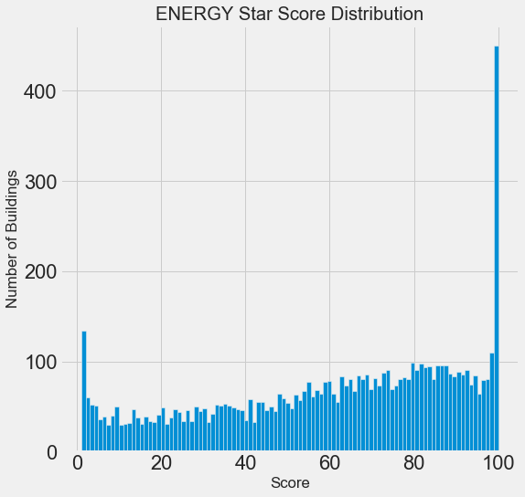

```python
figsize(8, 8)

# Histogram of the Energy Star Score
plt.style.use('fivethirtyeight')
plt.hist(train_labels['score'].dropna(), bins = 100);
plt.xlabel('Score'); plt.ylabel('Number of Buildings');
plt.title('ENERGY Star Score Distribution');
```

# Оценка и сравнение моделей машинного обучения

В этом разделе мы построим, обучим и оценим несколько методов машинного обучения для нашей задачи контролируемой регрессии. Цель состоит в том, чтобы определить, какая модель является наиболее перспективной для дальнейшего развития (например, настройка гиперпараметров). Мы сравниваем модели, используя среднюю абсолютную ошибку. Базовая модель, которая угадала среднее значение балла, была отклонена в среднем на 25 баллов.

## Заполняем отсутствующие значения

Хотя при очистке данных мы отбросили колонки, в которых не хватает больше половины значений, у нас ещё отсутствует немало значений. Модели машинного обучения не могут работать с отсутствующими данными, поэтому нам нужно их заполнить.

Мы делаем заполнение и не обучаем модель на данных как есть, чтобы избежать проблемы с утечкой тестовых данных, когда информация из тестового датасета переходит в обучающий.

```python
# Create an imputer object with a median filling strategy
imputer = SimpleImputer(missing_values=np.nan, strategy='mean')

# Train on the training features
imputer.fit(train_features)

# Transform both training data and testing data
X = imputer.transform(train_features)
X_test = imputer.transform(test_features)
```

```python
print('Missing values in training features: ', np.sum(np.isnan(X)))
print('Missing values in testing features:  ', np.sum(np.isnan(X_test)))
```

```
Missing values in training features:  0
Missing values in testing features:   0
```

```python
# Make sure all values are finite
print(np.where(~np.isfinite(X)))
print(np.where(~np.isfinite(X_test)))
```

```
(array([], dtype=int64), array([], dtype=int64))
(array([], dtype=int64), array([], dtype=int64))
```

Теперь все значения заполнены, пропусков нет.

### Масштабирование признаков

Масштабированием называется общий процесс изменения диапазона признака. Это необходимый шаг, потому что признаки измеряются в разных единицах, а значит покрывают разные диапазоны. Это сильно искажает результаты таких алгоритмов, как метод опорных векторов и метод k-ближайших соседей, которые учитывают расстояния между измерениями. А масштабирование позволяет этого избежать. И хотя методы вроде линейной регрессии и «случайного леса» не требует масштабирования признаков, лучше не пренебрегать этим этапом при сравнении нескольких алгоритмов.

Масштабировать будем с помощью приведения каждого признака к диапазону от 0 до 1. Берём все значения признака, выбираем минимальное и делим его на разницу между максимальным и минимальным (диапазон). Такой способ масштабирования часто называют нормализацией, а другой основной способ — стандартизацией.

Этот процесс легко реализовать вручную, поэтому воспользуемся объектом MinMaxScaler из Scikit-Learn. Код для этого метода идентичен коду для заполнения отсутствующих значений, только вместо вставки применяется масштабирование. Напомним, что учим модель только на обучающем наборе, а затем преобразуем все данные.

```python
# Create the scaler object with a range of 0-1
scaler = MinMaxScaler(feature_range=(0, 1))

# Fit on the training data
scaler.fit(X)

# Transform both the training and testing data
X = scaler.transform(X)
X_test = scaler.transform(X_test)
```

```python
# Convert y to one-dimensional array (vector)
y = np.array(train_labels).reshape((-1, ))
y_test = np.array(test_labels).reshape((-1, ))
```

Теперь у каждого признака минимальное значение равно 0, а максимальное 1. Заполнение отсутствующих значений и масштабирование признаков — эти два этапа нужны почти в любом процессе машинного обучения.

## Реализуем в Scikit-Learn модели машинного обучения

Мы будем оценивать пять моделей разной степени сложности:

1. Линейная регрессия.
2. Метод k-ближайших соседей.
3. «Случайный лес».
4. Градиентный бустинг.
5. Метод опорных векторов.

Для сравнения моделей мы будем в основном использовать значения по умолчанию Scikit-Learn для гиперпараметров модели. Как правило, они будут работать прилично, но должны быть оптимизированы перед фактическим использованием модели. Сначала мы просто хотим определить базовую производительность каждой модели, а затем мы можем выбрать наиболее эффективную модель для дальнейшей оптимизации с помощью настройки гиперпараметров. Помните, что гиперпараметры по умолчанию будут получать модель и работать, но почти всегда должны быть скорректированы с помощью какого-то поиска, чтобы найти лучшие настройки для вашей проблемы!

Всего по одной строке кода на создание, обучение и тестирование. Для построения других моделей воспользуемся тем же синтаксисом, меняя только название алгоритма.

```python
# Function to calculate mean absolute error
def mae(y_true, y_pred):
    return np.mean(abs(y_true - y_pred))

# Takes in a model, trains the model, and evaluates the model on the test set
def fit_and_evaluate(model):

    # Train the model
    model.fit(X, y)

    # Make predictions and evalute
    model_pred = model.predict(X_test)
    model_mae = mae(y_test, model_pred)

    # Return the performance metric
    return model_mae
```

```python
lr = LinearRegression()
lr_mae = fit_and_evaluate(lr)

print('Linear Regression Performance on the test set: MAE = %0.4f' % lr_mae)
```

```
Linear Regression Performance on the test set: MAE = 13.4901
```

```python
svm = SVR(C = 1000, gamma = 0.1)
svm_mae = fit_and_evaluate(svm)

print('Support Vector Machine Regression Performance on the test set: MAE = %0.4f' % svm_mae)
```

```
Support Vector Machine Regression Performance on the test set: MAE = 11.1165
```

```python
random_forest = RandomForestRegressor(random_state=17)
random_forest_mae = fit_and_evaluate(random_forest)

print('Random Forest Regression Performance on the test set: MAE = %0.4f' % random_forest_mae)
```

```
Random Forest Regression Performance on the test set: MAE = 10.0646
```

```python
gradient_boosted = GradientBoostingRegressor(random_state=60)
gradient_boosted_mae = fit_and_evaluate(gradient_boosted)

print('Gradient Boosted Regression Performance on the test set: MAE = %0.4f' % gradient_boosted_mae)
```

```
Gradient Boosted Regression Performance on the test set: MAE = 10.0552
```

```python
knn = KNeighborsRegressor(n_neighbors=10)
knn_mae = fit_and_evaluate(knn)

print('K-Nearest Neighbors Regression Performance on the test set: MAE = %0.4f' % knn_mae)
```

```
K-Nearest Neighbors Regression Performance on the test set: MAE = 13.0343
```

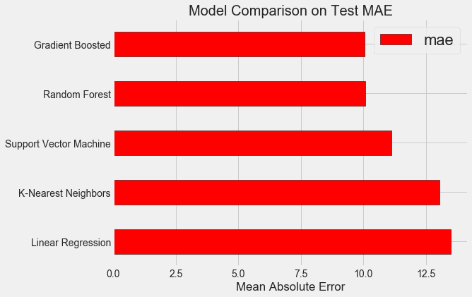

```python
plt.style.use('fivethirtyeight')
figsize(8, 6)

# Dataframe to hold the results
model_comparison = pd.DataFrame({'model': ['Linear Regression', 'Support Vector Machine',
                                           'Random Forest', 'Gradient Boosted',
                                            'K-Nearest Neighbors'],
                                 'mae': [lr_mae, svm_mae, random_forest_mae,
                                         gradient_boosted_mae, knn_mae]})

# Horizontal bar chart of test mae
model_comparison.sort_values('mae', ascending = False).plot(x = 'model', y = 'mae', kind = 'barh',
                                                           color = 'red', edgecolor = 'black')

# Plot formatting
plt.ylabel(''); plt.yticks(size = 14); plt.xlabel('Mean Absolute Error'); plt.xticks(size = 14)
plt.title('Model Comparison on Test MAE', size = 20);
```

# Гиперпараметрическая оптимизация модели

После выбора модели можно оптимизировать её под решаемую задачу, настраивая гиперпараметры. Но прежде всего давайте разберёмся, что такое гиперпараметры и чем они отличаются от обычных параметров?

- Гиперпараметры модели можно считать настройками алгоритма, которые мы задаём до начала его обучения. Например, гиперпараметром является количество деревьев в «случайном лесе», или количество соседей в методе k-ближайших соседей.
- Параметры модели — то, что она узнаёт в ходе обучения, например, веса в линейной регрессии.

Управляя гиперпараметром, мы влияем на результаты работы модели, меняя баланс между её недообучением и переобучением. Недообучением называется ситуация, когда модель недостаточно сложна (у неё слишком мало степеней свободы) для изучения соответствия признаков и цели. У недообученной модели высокое смещение (bias), которое можно скорректировать посредством усложнения модели. Переобучением называется ситуация, когда модель по сути запоминает учебные данные. У переобученной модели высокая дисперсия (variance), которую можно скорректировать с помощью ограничения сложности модели посредством регуляризации. Как недообученная, так и переобученная модель сможет хорошо обобщить тестовые данные. Трудность выбора правильных гиперпараметров заключается в том, что для каждой задачи будет уникальный оптимальный набор. Поэтому единственный способ выбрать наилучшие настройки — попробовать разные комбинации на новом датасете. К счастью, в Scikit-Learn есть ряд методов, позволяющих эффективно оценивать гиперпараметры.

## Случайный поиск с перекрёстной проверкой

Давайте реализуем метод настройки гиперпараметров, который называется случайным поискок с перекрёстной проверкой:

- Случайный поиск — методика выбора гиперпараметров. Мы определяем сетку, а потом из неё случайно выбираем различные комбинации, в отличие от сеточного поиска (grid search), при котором мы последовательно пробуем каждую комбинацию. Кстати, случайный поиск работает почти так же хорошо, как и сеточный, но гораздо быстрее.
- Перекрёстной проверкой называется способ оценки выбранной комбинации гиперпараметров. Вместо разделения данных на обучающий и тестовый наборы, что уменьшает количество доступных для обучения данных, мы воспользуемся k-блочной перекрёстной проверкой (K-Fold Cross Validation). Для этого мы разделим обучающие данные на k блоков, а затем прогоним итеративный процесс, в ходе которого сначала обучим модель на k-1 блоках, а затем сравним результат при обучении на k-ом блоке. Будем повторять процесс k раз, и в конце получим среднее значение ошибки для каждой итерации. Это и будет финальная оценка.

Начать можно с алгоритма RandomizedSearchCV, который позволяет довольно грубо исследовать широкие диапазоны значений. В ходе работы мы генерируем сущность hyperparameter_grid, содержащую, для каждого гиперпараметра, диапазон значений, которые нужно испытать. Далее, мы инициализируем объект random_cv с помощью функции RandomizedSearchCV(), передавая ей модель, hyperparameter_grid, число итераций и число кросс-валидаций, которые нужно выполнить.

Гиперпараметр verbose позволяет управлять объёмом информации, который выводится моделью в ходе её работы (наподобие вывода сведений в процессе обучения модели). Гиперпараметр n_jobs позволяет указывать то, сколько процессорных ядер нужно использовать для обеспечения работы модели. Установка n_jobs в значение -1 приведёт к более быстрой работе модели, так как при этом будут использоваться все ядра процессора.

В регрессии с помощью градиентного бустинга есть много гиперпараметров, которые нужно настраивать, за подробностями отсылаю вас к документации Scikit-Learn. Мы будем оптимизировать:

- loss: минимизация функции потерь;
- n_estimators: количество используемых слабых деревьев решений (decision trees);
- max_depth: максимальная глубина каждого дерева решений;
- min_samples_leaf: минимальное количество примеров, которые должны быть в «листовом» (leaf) узле дерева решений;
- min_samples_split: минимальное количество примеров, которые нужны для разделения узла дерева решений;
- max_features: максимальное количество признаков, которые используются для разделения узлов.

Единственный способ найти лучшую комбинацию — перепробовать разные варианты.

В этом коде мы создаём сетку из гиперпараметров, затем создаём объект RandomizedSearchCV и ищем с помощью 4-блочной перекрёстной проверки по 25 разным комбинациям гиперпараметров:

```python
# Loss function to be optimized
loss = ['ls', 'lad', 'huber']

# Number of trees used in the boosting process
n_estimators = [100, 500, 900, 1100, 1500]

# Maximum depth of each tree
max_depth = [2, 3, 5, 10, 15]

# Minimum number of samples per leaf
min_samples_leaf = [1, 2, 4, 6, 8]

# Minimum number of samples to split a node
min_samples_split = [2, 4, 6, 10]

# Maximum number of features to consider for making splits
max_features = ['auto', 'sqrt', 'log2', None]

bootstrap = [True, False]

# Define the grid of hyperparameters to search
hyperparameter_grid = {'loss': loss,
                       'n_estimators': n_estimators,
                       'max_depth': max_depth,
                       'min_samples_leaf': min_samples_leaf,
                       'min_samples_split': min_samples_split,
                       'max_features': max_features}
```

В приведенном ниже коде мы создаем рандомизированный объект поиска (random_cv), передающий следующие параметры:

- `estimator`: модель
- `param_distributions`: распределение параметров, которые мы определили
- `cv` количество разбиений для K-кратной перекрестной проверки
- `n_iter`: количество итераций
- `scoring`: какую метрику следует использовать при оценке кандидатов
- `n_jobs`: оличество ядер для параллельной работы (-1 будет использовать все доступные)
- `verbose`: сколько информации нужно отобразить (1 отображает ограниченное количество)
- `return_train_score`: возвращает тренировочный балл для каждого раза перекрестной проверки
- `random_state`: для воспроизводимости результатов

Рандомизированный объект поиска обучается так же, как и любая другая модель scikit-learn. После тренировки мы можем сравнить все различные комбинации гиперпараметров и найти наиболее эффективный из них.

```python
# Create the model to use for hyperparameter tuning
model = GradientBoostingRegressor(random_state = 42)

# Set up the random search with 4-fold cross validation
random_cv = RandomizedSearchCV(estimator=model,
                               param_distributions=hyperparameter_grid,
                               cv=4, n_iter=25,
                               scoring = 'neg_mean_absolute_error',
                               n_jobs = -1, verbose = 1,
                               return_train_score = True,
                               random_state=42)
```

```python
# Fit on the training data
random_cv.fit(X, y)
random_cv.best_params_
```

```
Fitting 4 folds for each of 25 candidates, totalling 100 fits
```

```
[Parallel(n_jobs=-1)]: Using backend LokyBackend with 4 concurrent workers.
[Parallel(n_jobs=-1)]: Done  42 tasks      | elapsed: 32.3min
[Parallel(n_jobs=-1)]: Done 100 out of 100 | elapsed: 56.4min finished
```

```
{'n_estimators': 500,
 'min_samples_split': 6,
 'min_samples_leaf': 6,
 'max_features': None,
 'max_depth': 5,
 'loss': 'lad'}
```

Мы можем обратиться к атрибуту best*params* для получения сведений о наборе параметров, позволяющем создать самую лучшую модель. Но на данной стадии это может не дать нам наиболее интересных данных о диапазонах параметров, которые стоит изучить на следующем раунде оптимизации. Для того чтобы выяснить то, в каком диапазоне значений стоит продолжать поиск, мы легко можем получить датафрейм, содержащий результаты работы алгоритма RandomizedSearchCV.

```python
# Get all of the cv results and sort by the test performance
random_results = pd.DataFrame(random_cv.cv_results_).sort_values('mean_test_score', ascending = False)
random_results.head(10)
```

|  | mean_fit_time | std_fit_time | mean_score_time | std_score_time | param_n_estimators | param_min_samples_split | param_min_samples_leaf | param_max_features | param_max_depth | param_loss | params | split0_test_score | split1_test_score | split2_test_score | split3_test_score | mean_test_score | std_test_score | rank_test_score | split0_train_score | split1_train_score | split2_train_score | split3_train_score | mean_train_score | std_train_score |
| --- | --- | --- | --- | --- | --- | --- | --- | --- | --- | --- | --- | --- | --- | --- | --- | --- | --- | --- | --- | --- | --- | --- | --- | --- |
| 12 | 85.439603 | 1.883822 | 0.065000 | 0.004362 | 500 | 6 | 6 | None | 5 | lad | {'n_estimators': 500, 'min_samples_split': 6, ... | -8.983093 | -8.986238 | -9.492453 | -9.056275 | -9.129471 | 0.211558 | 1 | -6.858645 | -7.123152 | -6.696720 | -6.926004 | -6.901130 | 0.152890 |
| 3 | 93.196999 | 1.123758 | 0.069001 | 0.007692 | 500 | 6 | 8 | None | 5 | huber | {'n_estimators': 500, 'min_samples_split': 6, ... | -9.008554 | -8.997507 | -9.340318 | -9.172339 | -9.129641 | 0.139933 | 2 | -4.475540 | -4.243975 | -4.457727 | -4.260451 | -4.359423 | 0.107553 |
| 9 | 56.695408 | 1.777113 | 0.047004 | 0.008190 | 500 | 4 | 2 | auto | 3 | huber | {'n_estimators': 500, 'min_samples_split': 4, ... | -9.088540 | -9.001503 | -9.453808 | -9.304143 | -9.211948 | 0.177842 | 3 | -7.046088 | -7.137267 | -6.967090 | -7.041155 | -7.047900 | 0.060344 |
| 0 | 17.264356 | 0.180027 | 0.022005 | 0.004472 | 100 | 2 | 6 | auto | 5 | ls | {'n_estimators': 100, 'min_samples_split': 2, ... | -9.095681 | -9.025474 | -9.552921 | -9.389003 | -9.265708 | 0.214657 | 4 | -7.386599 | -7.361495 | -7.169365 | -7.424019 | -7.335369 | 0.098391 |
| 7 | 49.957966 | 1.926601 | 0.041994 | 0.001997 | 500 | 4 | 6 | auto | 3 | ls | {'n_estimators': 500, 'min_samples_split': 4, ... | -9.260041 | -9.173060 | -9.728909 | -9.439457 | -9.400311 | 0.212613 | 5 | -7.110814 | -7.085994 | -6.992949 | -7.101708 | -7.072866 | 0.046987 |
| 10 | 423.246920 | 16.692904 | 0.279001 | 0.047776 | 1100 | 10 | 6 | None | 10 | huber | {'n_estimators': 1100, 'min_samples_split': 10... | -9.307121 | -9.359731 | -9.569468 | -9.496260 | -9.433115 | 0.104689 | 6 | -0.363444 | -0.497071 | -0.386440 | -0.362319 | -0.402318 | 0.055546 |
| 2 | 255.221942 | 4.986185 | 0.148999 | 0.022690 | 500 | 4 | 2 | auto | 10 | huber | {'n_estimators': 500, 'min_samples_split': 4, ... | -9.504036 | -9.268878 | -9.666088 | -9.472607 | -9.477874 | 0.141261 | 7 | -0.161247 | -0.141086 | -0.149169 | -0.128999 | -0.145125 | 0.011754 |
| 16 | 158.435306 | 1.929598 | 0.132001 | 0.014144 | 1500 | 4 | 6 | None | 3 | ls | {'n_estimators': 1500, 'min_samples_split': 4,... | -9.297229 | -9.320128 | -9.786757 | -9.577448 | -9.495334 | 0.201001 | 8 | -4.838676 | -4.777318 | -4.815940 | -4.800022 | -4.807989 | 0.022411 |
| 19 | 132.159915 | 0.559087 | 0.103243 | 0.011273 | 1100 | 6 | 2 | auto | 3 | lad | {'n_estimators': 1100, 'min_samples_split': 6,... | -9.477411 | -9.398567 | -9.705020 | -9.573204 | -9.538520 | 0.114286 | 9 | -8.455818 | -8.612215 | -8.018586 | -8.635754 | -8.430593 | 0.247721 |
| 21 | 27.374844 | 1.199930 | 0.099251 | 0.018657 | 500 | 6 | 4 | log2 | 5 | huber | {'n_estimators': 500, 'min_samples_split': 6, ... | -9.487825 | -9.365147 | -9.820085 | -9.481934 | -9.538714 | 0.169627 | 10 | -5.643874 | -5.744674 | -5.620299 | -5.634947 | -5.660949 | 0.049066 |

```python
random_cv.best_estimator_
```

```
GradientBoostingRegressor(alpha=0.9, criterion='friedman_mse', init=None,
                          learning_rate=0.1, loss='lad', max_depth=5,
                          max_features=None, max_leaf_nodes=None,
                          min_impurity_decrease=0.0, min_impurity_split=None,
                          min_samples_leaf=6, min_samples_split=6,
                          min_weight_fraction_leaf=0.0, n_estimators=500,
                          n_iter_no_change=None, presort='auto',
                          random_state=42, subsample=1.0, tol=0.0001,
                          validation_fraction=0.1, verbose=0, warm_start=False)
```

Теперь создадим столбчатые графики, на которых, по оси Х, расположены значения гиперпараметров, а по оси Y — средние значения, показываемые моделями. Это позволит понять то, какие значения гиперпараметров, в среднем, лучше всего себя показывают.

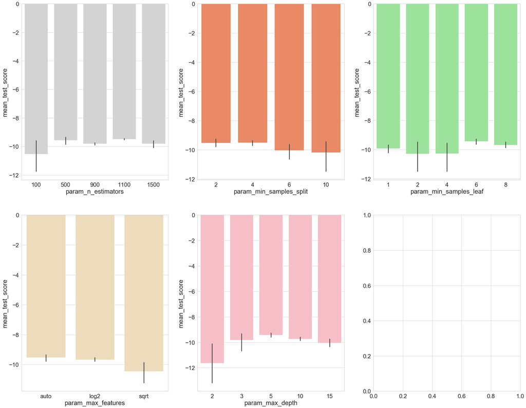

```python
fig, axs = plt.subplots(ncols=3, nrows=2)
sns.set(style="whitegrid", color_codes=True, font_scale = 2)
fig.set_size_inches(30,25)
sns.barplot(x='param_n_estimators', y='mean_test_score', data=random_results, ax=axs[0,0], color='lightgrey')
sns.barplot(x='param_min_samples_split', y='mean_test_score', data=random_results, ax=axs[0,1], color='coral')
sns.barplot(x='param_min_samples_leaf', y='mean_test_score', data=random_results, ax=axs[0,2], color='lightgreen')
sns.barplot(x='param_max_features', y='mean_test_score', data=random_results, ax=axs[1,0], color='wheat')
sns.barplot(x='param_max_depth', y='mean_test_score', data=random_results, ax=axs[1,1], color='lightpink')
plt.show()
```

Если проанализировать вышеприведённые графики, то можно заметить некоторые интересные вещи, говорящие о том, как, в среднем, каждое значение гиперпараметра влияет на модель.

После применения алгоритма RandomizedSearchCV воспользуемся алгоритмом GridSearchCV для проведения более точного поиска наилучшей комбинации гиперпараметров. Здесь исследуются те же гиперпараметры, но теперь мы применяем более «обстоятельный» поиск их наилучшей комбинации. При использовании алгоритма GridSearchCV исследуется каждая комбинация гиперпараметров. Это требует гораздо больших вычислительных ресурсов, чем использование алгоритма RandomizedSearchCV, когда мы самостоятельно задаём число итераций поиска. Например, исследование 10 значений для каждого из 6 гиперпараметров с кросс-валидацией по 3 блокам потребует 10⁶ x 3, или 3000000 сеансов обучения модели. Именно поэтому мы и используем алгоритм GridSearchCV после того, как, применив RandomizedSearchCV, сузили диапазоны значений исследуемых параметров.

Использование случайного поиска является хорошим методом, чтобы сузить возможные гиперпараметры, чтобы попробовать. Изначально мы понятия не имели, какая комбинация будет работать лучше всего, но это, по крайней мере, сужает диапазон вариантов.

Мы могли бы использовать результаты случайного поиска для получения информации о сеточном поиске, создав сетку с гиперпараметрами, близкими к тем, которые лучше всего работали во время рандомизированного поиска. Однако вместо того, чтобы снова оценивать все эти параметры, сосредоточимся на одном-количестве деревьев в лесу (n_estimators). Изменяя только один гиперпараметр, мы можем непосредственно наблюдать, как он влияет на производительность. В случае с количеством деревьев мы ожидали бы увидеть значительное влияние на величину недообучения и переобучения.

Итак, используя то, что мы выяснили с помощью RandomizedSearchCV, исследуем значения гиперпараметров, которые лучше всего себя показали:

```python
# Create a range of trees to evaluate
trees_grid = {'n_estimators': [100, 150, 200, 250, 300, 350, 400, 450, 500, 550, 600, 650, 700, 750, 800, 1100]}

model = GradientBoostingRegressor(loss = 'lad', max_depth = 5,
                                  min_samples_leaf =6,
                                  min_samples_split =4,
                                  max_features = None,
                                  random_state = 42)

# Grid Search Object using the trees range and the random forest model
grid_search = GridSearchCV(estimator = model, param_grid=trees_grid, cv = 4,
                           scoring = 'neg_mean_absolute_error', verbose = 1,
                           n_jobs = -1, return_train_score = True)
```

```python
# Fit the grid search
grid_search.fit(X, y)
```

```
Fitting 4 folds for each of 16 candidates, totalling 64 fits
```

```
[Parallel(n_jobs=-1)]: Using backend LokyBackend with 4 concurrent workers.
[Parallel(n_jobs=-1)]: Done  42 tasks      | elapsed: 13.5min
[Parallel(n_jobs=-1)]: Done  64 out of  64 | elapsed: 33.3min finished
```

```
GridSearchCV(cv=4, error_score='raise-deprecating',
             estimator=GradientBoostingRegressor(alpha=0.9,
                                                 criterion='friedman_mse',
                                                 init=None, learning_rate=0.1,
                                                 loss='lad', max_depth=5,
                                                 max_features=None,
                                                 max_leaf_nodes=None,
                                                 min_impurity_decrease=0.0,
                                                 min_impurity_split=None,
                                                 min_samples_leaf=6,
                                                 min_samples_split=4,
                                                 min_weight_fraction_leaf=0.0,
                                                 n_estimators=100,
                                                 n_iter_no_change=None,
                                                 presort='auto',
                                                 random_state=42, subsample=1.0,
                                                 tol=0.0001,
                                                 validation_fraction=0.1,
                                                 verbose=0, warm_start=False),
             iid='warn', n_jobs=-1,
             param_grid={'n_estimators': [100, 150, 200, 250, 300, 350, 400,
                                          450, 500, 550, 600, 650, 700, 750,
                                          800, 1100]},
             pre_dispatch='2*n_jobs', refit=True, return_train_score=True,
             scoring='neg_mean_absolute_error', verbose=1)
```

И уже теперь, после того, как мы воспользовались RandomizedSearchCV и GridSearchCV, мы можем обратиться к атрибуту best*params* для того чтобы узнать о том, какие значения гиперпараметров позволяют модели наилучшим образом работать с исследуемым набором данных

Есть общее правило: грамотное конструирование признаков окажет на точность модели куда большее влияние, чем самая дорогая гиперпараметрическая настройка. Это закон убывания доходности применительно к машинному обучению: конструирование признаков даёт наивысшую отдачу, а гиперпараметрическая настройка приносит лишь скромную выгоду.

Для изменения количества оценщиков (estimator) (деревьев решений) с сохранением значений других гиперпараметров можно поставить один эксперимент, который продемонстрирует роль этой настройки. Реализация приведена здесь, а вот что получилось в результате:

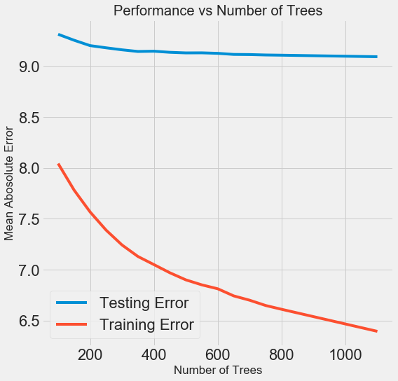

```python
# Get the results into a dataframe
results = pd.DataFrame(grid_search.cv_results_)

# Plot the training and testing error vs number of trees
figsize(8, 8)
plt.style.use('fivethirtyeight')
plt.plot(results['param_n_estimators'], -1 * results['mean_test_score'], label = 'Testing Error')
plt.plot(results['param_n_estimators'], -1 * results['mean_train_score'], label = 'Training Error')
plt.xlabel('Number of Trees'); plt.ylabel('Mean Abosolute Error'); plt.legend();
plt.title('Performance vs Number of Trees');
```

```python
results.sort_values('mean_test_score', ascending = False).head(5)
```

|  | mean_fit_time | std_fit_time | mean_score_time | std_score_time | param_n_estimators | params | split0_test_score | split1_test_score | split2_test_score | split3_test_score | mean_test_score | std_test_score | rank_test_score | split0_train_score | split1_train_score | split2_train_score | split3_train_score | mean_train_score | std_train_score |
| --- | --- | --- | --- | --- | --- | --- | --- | --- | --- | --- | --- | --- | --- | --- | --- | --- | --- | --- | --- |
| 15 | 322.267503 | 9.424833 | 0.138994 | 0.021787 | 1100 | {'n_estimators': 1100} | -8.954970 | -8.931367 | -9.434126 | -9.047549 | -9.091958 | 0.202228 | 1 | -6.438352 | -6.592529 | -6.191080 | -6.360547 | -6.395627 | 0.144625 |
| 14 | 259.667108 | 5.498239 | 0.212003 | 0.057520 | 800 | {'n_estimators': 800} | -8.961846 | -8.957303 | -9.461302 | -9.047552 | -9.106956 | 0.207676 | 2 | -6.590856 | -6.836508 | -6.433413 | -6.587810 | -6.612147 | 0.144334 |
| 13 | 267.316173 | 4.090133 | 0.222000 | 0.011300 | 750 | {'n_estimators': 750} | -8.961292 | -8.959668 | -9.466236 | -9.049469 | -9.109121 | 0.209316 | 3 | -6.623392 | -6.877051 | -6.464904 | -6.632223 | -6.649393 | 0.147339 |
| 12 | 187.030187 | 12.069071 | 0.238257 | 0.067254 | 700 | {'n_estimators': 700} | -8.976795 | -8.964471 | -9.472308 | -9.039403 | -9.113201 | 0.209227 | 4 | -6.667822 | -6.917818 | -6.518033 | -6.700811 | -6.701121 | 0.142818 |
| 11 | 135.317992 | 2.543240 | 0.108265 | 0.017001 | 650 | {'n_estimators': 650} | -8.974035 | -8.963478 | -9.480754 | -9.040387 | -9.114619 | 0.213391 | 5 | -6.730029 | -6.949416 | -6.561048 | -6.734231 | -6.743681 | 0.137802 |

# Оценка с помощью тестовых данных

Будучи ответственными людьми мы удостоверились, что наша модель никоим образом не получала доступ к тестовым данным в ходе обучения. Поэтому точность при работе с тестовыми данными мы можем использовать в роли индикатора качества модели, когда её допустят к реальным задачам.

```python
# Default model
default_model = GradientBoostingRegressor(random_state = 42)

# Select the best model
final_model = grid_search.best_estimator_

final_model
```

```
GradientBoostingRegressor(alpha=0.9, criterion='friedman_mse', init=None,
                          learning_rate=0.1, loss='lad', max_depth=5,
                          max_features=None, max_leaf_nodes=None,
                          min_impurity_decrease=0.0, min_impurity_split=None,
                          min_samples_leaf=6, min_samples_split=4,
                          min_weight_fraction_leaf=0.0, n_estimators=1100,
                          n_iter_no_change=None, presort='auto',
                          random_state=42, subsample=1.0, tol=0.0001,
                          validation_fraction=0.1, verbose=0, warm_start=False)
```

Сравнить длительность обучения обеих моделей можно с помощью волшебной команды %timeit в Jupyter Notebooks. Сначала измерим длительность работы модели по умолчанию:

```python
%%timeit -n 1 -r 5
default_model.fit(X, y)
```

```
3.67 s ± 187 ms per loop (mean ± std. dev. of 5 runs, 1 loop each)
```

Четыре секунды на обучение — очень прилично. А вот настроенная модель уже не такая шустрая:

```python
%%timeit -n 1 -r 5
final_model.fit(X, y)
```

```
1min 24s ± 364 ms per loop (mean ± std. dev. of 5 runs, 1 loop each)
```

```python
default_pred = default_model.predict(X_test)
final_pred = final_model.predict(X_test)

print('Default model performance on the test set: MAE = %0.4f.' % mae(y_test, default_pred))
print('Final model performance on the test set:   MAE = %0.4f.' % mae(y_test, final_pred))
```

```
Default model performance on the test set: MAE = 10.0584.
Final model performance on the test set:   MAE = 9.0559.
```

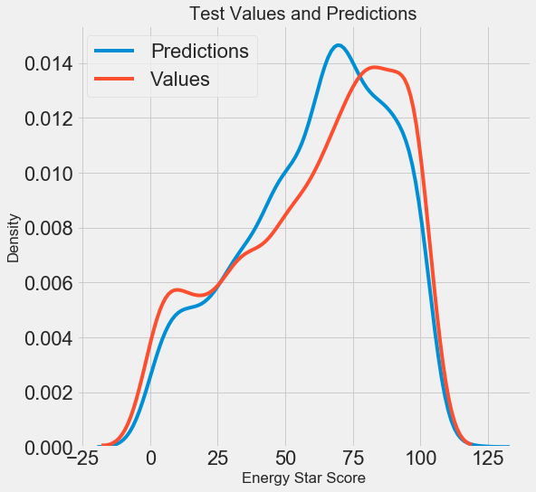

```python
figsize(8, 8)

# Density plot of the final predictions and the test values
sns.kdeplot(final_pred, label = 'Predictions')
sns.kdeplot(y_test, label = 'Values')

# Label the plot
plt.xlabel('Energy Star Score'); plt.ylabel('Density');
plt.title('Test Values and Predictions');
```

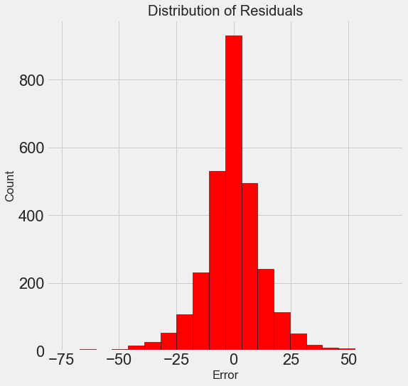

```python
figsize = (6, 6)

# Calculate the residuals
residuals = final_pred - y_test

# Plot the residuals in a histogram
plt.hist(residuals, color = 'red', bins = 20,
         edgecolor = 'black')
plt.xlabel('Error'); plt.ylabel('Count')
plt.title('Distribution of Residuals');
```

### Вывод:

Результаты свидетельствуют, что мы можем применять машинное обучение для прогнозирования баллов расхода энергии на основе доступной статистики. С помощью градиентного бустинга удалось на тестовых данных добиться погрешности в пределах 9,1. Гиперпараметрическая настройка может сильно улучшить результаты, но ценой значительного замедления работы. Это один из многих компромиссов, которые нужно учитывать в машинном обучении.